# How reproducible is ecology?

Aud and Matt

## Reproducibilty

[figure not shown]

The Turing Way Community. This illustration is created by Scriberia with The Turing Way community, used under a CC-BY 4.0 licence. DOI: 10.5281/zenodo.3332807

## Data and code availability

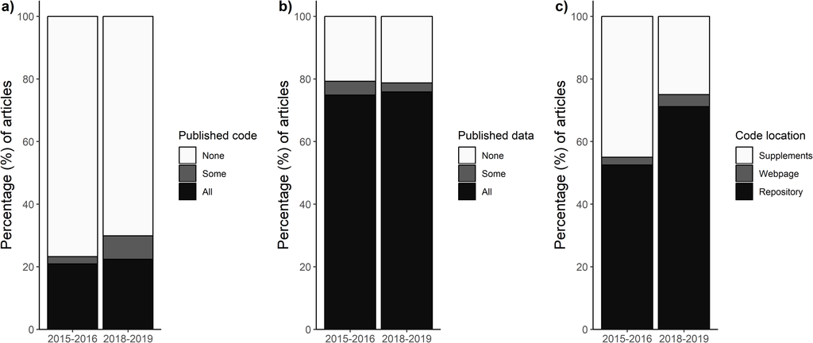

Culina A, van den Berg I, Evans S, Sánchez-Tójar A (2020) Low availability of code in ecology: A call for urgent action. PLOS Biology 18(7): e3000763. https://doi.org/10.1371/journal.pbio.3000763

### 2023: Review 87 papers from 6 journals

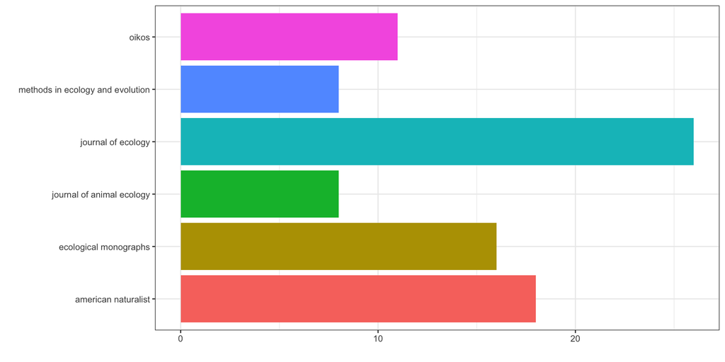

### 2023: data and code availability

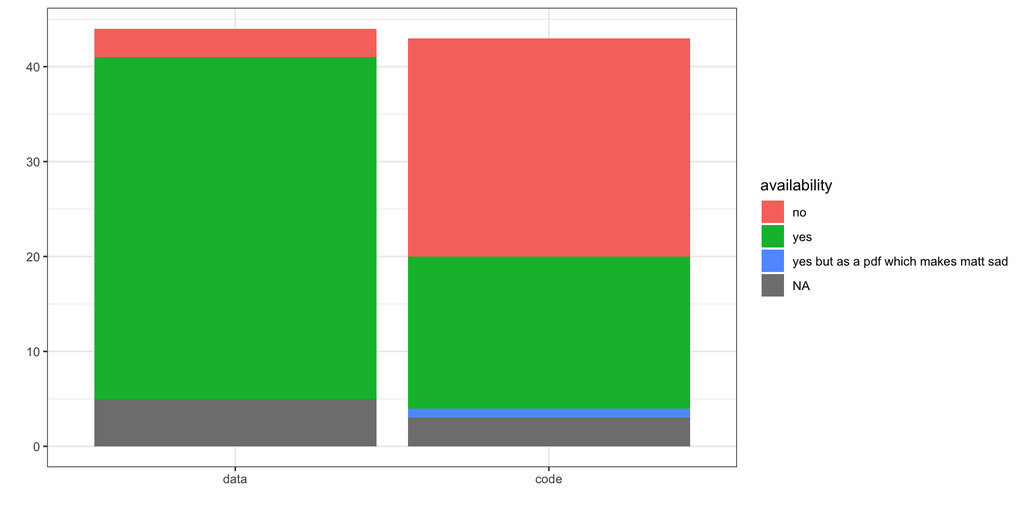

Figure 1: Data and code availability.

### 2023: data and code availability

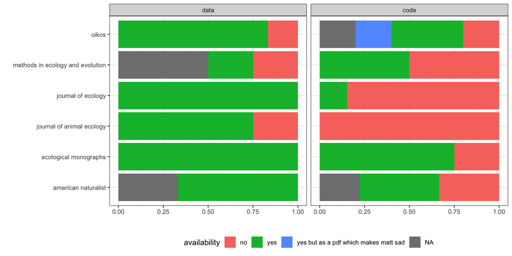

Figure 2

## Exercise (1/2)

Make groups of 3-4.

Choose one of the following journals and select a random issue from 2024:

- Methods in Ecology and Evolution
- Journal of Ecology
- OIKOS
- American Naturalist
- Journal of Animal Ecology
- Ecological Monographs

## Exercise (2/2)

For each paper in this issue check:

- Is the **data available** and can you download it? Repo or supplement file? In what format is the data available (xlsx, csv, txt, etc.)?
- Is the **code available**? Choose one figure/analysis. Is the data and code for this figure/analysis available? Try to run the code, can you replicate the figure/analysis.
- Add the data to this [google spreadsheet](https://docs.google.com/spreadsheets/d/1Rde3TsuFsExDmNNROZqslWVUOl_dXaLp4V-LnHq3Fyw/edit?gid=1921182395#gid=1921182395) and get a snack 🍪